# Economic Connectedness (city)

Author

Ridhi Purohit and Tina Chelidze

Published

February 25, 2025

**Creating the second Social Capital metric, Economic Connectedness**

This program creates the city-level Economic Connectedness metric which is one of the two Social Capital UMF Metrics.

Author: This code was initially written by Tina Chelidze (see `06_neighborhoods/social-capital/economic_connectedness_city_code_2022.R`) and updated by Ridhi Purohit in January, 2025.

Data downloaded from the [Opportunity Insights Social Capital Atlas](https://socialcapital.org/).

## Housekeeping

This update will change the way the metric is calculated to align with the changed way economic connectedness is displayed through the Social Capital Atlas.

The process to create the metric will follow these steps:

1. download data from socialcapital.org
2. import and clean the data file
3. merge with the 2010 ZCTA -> 2021 Census Place crosswalk
4. collapse estimates to unique Places
5. check against official Census Place file & limit to population cutoff Places
6. update economic connectedness variable and create data quality flag
7. final file cleaning and export to csv file

Load the packages used in this program.

```r
options(scipen = 999)

librarian::shelf(
  sf,
  tidyverse,
  here,
  UrbanInstitute / urbnthemes
  )

set_urbn_defaults(style = "print")

# source the final data evaluation function
source(here::here("functions", "testing", "evaluate_final_data.R"))
```

## Download data from the Social Capital Atlas

The data is accessed from the Social Capital [website](https://data.humdata.org/dataset/social-capital-atlas).

NOTE: in the paper (https://opportunityinsights.org/wp-content/uploads/2022/07/social-capital1_wp.pdf), the authors state that “Zip Codes” is shorthand for 2010 ZCTA designations

```r
# Specify URL where source data file is online
url <- "https://data.humdata.org/dataset/85ee8e10-0c66-4635-b997-79b6fad44c71/resource/ab878625-279b-4bef-a2b3-c132168d536e/download/social_capital_zip.csv"

# Specify destination where file should be saved (the .gitignore folder for your local branch)
destfile <- here::here("06_neighborhoods", "social-capital", "temp","social_capital_zip.csv")

# Import the data file & save locally
download.file(url, destfile)
```

## Clean the data

This step involves cleaning the data so that zip and state codes are identifiable. Any missing data will also be dealt with.

```r
# read data
ec_zip_raw <- read.csv(here::here("06_neighborhoods", "social-capital", "temp", "social_capital_zip.csv"))

# check the columns present in the data
names(ec_zip_raw)
```

```
 [1] "zip"                       "county"
 [3] "num_below_p50"             "pop2018"
 [5] "ec_zip"                    "ec_se_zip"
 [7] "nbhd_ec_zip"               "ec_grp_mem_zip"
 [9] "ec_high_zip"               "ec_high_se_zip"
[11] "nbhd_ec_high_zip"          "ec_grp_mem_high_zip"
[13] "exposure_grp_mem_zip"      "exposure_grp_mem_high_zip"
[15] "nbhd_exposure_zip"         "bias_grp_mem_zip"
[17] "bias_grp_mem_high_zip"     "nbhd_bias_zip"
[19] "nbhd_bias_high_zip"        "clustering_zip"
[21] "support_ratio_zip"         "volunteering_rate_zip"
[23] "civic_organizations_zip"
```

In the data, `ec_zip` is the Economic Connectedness variable for a zip code and `ec_se_zip` is the corresponding standard error in calculating `ec_zip`.

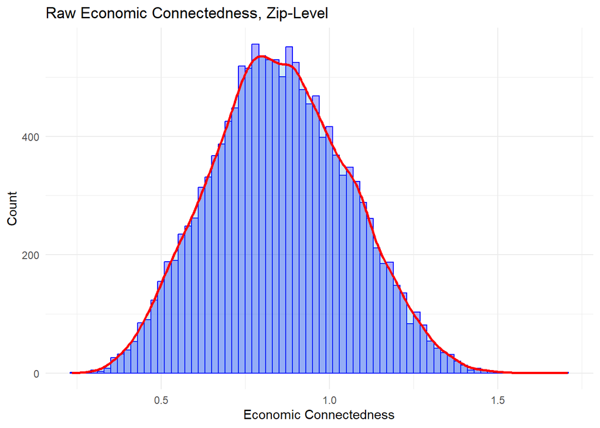

```r
ec_zip_raw |>
    drop_na() |>
    ggplot(aes(x = ec_zip)) +
    geom_histogram(color = "blue", fill = alpha("blue", 0.3), binwidth = 0.02) +
    geom_density(aes(y = ..count.. * 0.02), color = "red", size = 1, alpha = 0.2) +
    labs(
      title = paste0("Raw Economic Connectedness, Zip-Level"),
      y = "Count",
      x = "Economic Connectedness"
    ) +
    theme_minimal()
```

The plot above shows the distribution of economic connectedness defined as “the share of friends with above-median SES (‘high SES’) among people with below-median SES (‘low SES’) divided by 50%, to quantify the average degree of under-representation of high-SES friends among people with low SES.”

Here, a value of 1 indicates that a community is perfectly integrated across socioeconomic status. Values closer to 0 or 2 indicate that a community is less integrated across socioeconomic status.

Clean the data by standardizing the format of of zip, county, and state FIPS codes, and removing N/A values.

```r
ec_zip_raw <- ec_zip_raw |>
            mutate(
              # add leading zeroes where they are missing (ZCTA codes are 5 digits)
              zip = str_pad(zip, width = 5, pad = "0", side = "left"),
              #add leading zeroes where they are missing for the concatenated FIPS (2 state + 3 county)
              county = str_pad(county, width = 5, pad = "0", side = "left")
              ) |>
             # create a new column for the state & county FIPS
             mutate(
                state = str_sub(county, start = 1, end = 2),
                county = str_sub(county, start = 3, end = 5)
              ) |>
            # keep only relevant data
            select(state, county, zip, ec_zip, ec_se_zip)

# find if there are missing values for `ec_zip` in the data
sum(is.na(ec_zip_raw$ec_zip))
```

```
[1] 4048
```

```r
### There were 4048 missing observations from a total of 23028 observations

# remove observations with missing data for our Economic Connectedness variable
ec_zip_raw <- ec_zip_raw |>
            drop_na(ec_zip)
```

## Merge Crosswalk

We will use a 2010 ZCTA -> 2021 Census Place crosswalk to get a master list of places which will also allow us to assess missingness in the data.

The zip codes i.e. ZCTA (ZIP Code Tabulation Areas), state and place FIPS codes in the data need to be cleaned up.

```r
# import the relevant crosswalk file
ZCTA_Place <- read_csv(
                    here::here("geographic-crosswalks", "data",
                               "2010_ZCTA_2021_Census_Places_Crosswalk.csv")
                    )

## clean up the crosswalk file to prepare for the merge

# rename the ZCTA and other FIPS variables to avoid confusion
ZCTA_Place <- ZCTA_Place |>
        rename(
          zip = ZCTA5CE10,
          state = STATEFP,
          place = PLACEFP,
          place_name = NAMELSAD
          ) |>
        # adjust the leading zeroes to 5 digit zip codes, 2 digit state codes and 5 digit place codes
        mutate(
              zip = sprintf("%0.5d", as.numeric(zip)),
              state = sprintf("%0.2d", as.numeric(state)),
              place = sprintf("%0.5d", as.numeric(place))
              )
```

Next, we create a variable `portion_in` to indicate whether a ZIP area entirely falls inside a Census designated `Place`. Another variable `mostly_in` was created to find the ZIP areas where more than 50% of the area falls inside a `Place`.

```r
# make an indicator for ZIPs that fall wholly into a Place vs. partially (ZCTAinPlace < 1)
ZCTA_Place <- ZCTA_Place |>
        mutate(portion_in = case_when(
                                      ZCTAinPlace == 1 ~ 1,
                                      ZCTAinPlace < 1 ~ 0)
               )

# check how many of these fall fully into a Census Place
sum(with(ZCTA_Place, portion_in == 1))
```

```
[1] 2079
```

```r
## Observation: 2079 of these ZCTAs fall fully into a Census Place

summary(ZCTA_Place)
```

```
     zip             AFFGEOID10          GEOID10             ALAND10
 Length:71790       Length:71790       Length:71790       Min.   :       5421
 Class :character   Class :character   Class :character   1st Qu.:   27297241
 Mode  :character   Mode  :character   Mode  :character   Median :   93072806
                                                          Mean   :  254476592
                                                          3rd Qu.:  242822910
                                                          Max.   :34881054727
    AWATER10             ZCTAarea              state
 Min.   :         0   Min.   :       2709   Length:71790
 1st Qu.:    127148   1st Qu.:   28406443   Class :character
 Median :    871557   Median :   96058914   Mode  :character
 Mean   :   6490495   Mean   :  259434791
 3rd Qu.:   3623498   3rd Qu.:  247093654
 Max.   :2474993318   Max.   :35198234656
    place             PLACENS            AFFGEOID            GEOID
 Length:71790       Length:71790       Length:71790       Length:71790
 Class :character   Class :character   Class :character   Class :character
 Mode  :character   Mode  :character   Mode  :character   Mode  :character



     NAME            place_name           STUSPS           STATE_NAME
 Length:71790       Length:71790       Length:71790       Length:71790
 Class :character   Class :character   Class :character   Class :character
 Mode  :character   Mode  :character   Mode  :character   Mode  :character



     LSAD               ALAND                AWATER
 Length:71790       Min.   :     13088   Min.   :         0
 Class :character   1st Qu.:   2887730   1st Qu.:         0
 Mode  :character   Median :   8875371   Median :     52766
                    Mean   :  57239719   Mean   :   5963383
                    3rd Qu.:  30001291   3rd Qu.:    592633
                    Max.   :7433415763   Max.   :5037747535
 IntersectArea         ZCTAinPlace       portion_in
 Min.   :         0   Min.   :0.0000   Min.   :0.00000
 1st Qu.:     27821   1st Qu.:0.0010   1st Qu.:0.00000
 Median :   1315169   Median :0.0100   Median :0.00000
 Mean   :   7181029   Mean   :0.1314   Mean   :0.02896
 3rd Qu.:   6142527   3rd Qu.:0.0720   3rd Qu.:0.00000
 Max.   :5949271835   Max.   :1.0000   Max.   :1.00000
```

```r
## Observation for ZCTAinPlace: mean = 0.13, Q3 = 0.072

# find boundaries (I did not end up using this, but leaving it in)
# make a more detailed indicator for portion of ZIPs falling into each census place
ZCTA_Place <- ZCTA_Place |>
        mutate(
          mostly_in = case_when(
                                ZCTAinPlace >= 0.5 ~ 1,
                                ZCTAinPlace < 0.5 ~ 0)
          )

# keep only the variables we will need
ZCTA_Place <- ZCTA_Place |>
                    select(
                      zip, state, place, place_name, IntersectArea, ZCTAinPlace,
                      portion_in, mostly_in)
```

Visualize the `ZCTAinPlace` variable to see if any outliers exist. We also bin the variable into three broad groups to check the distribution.

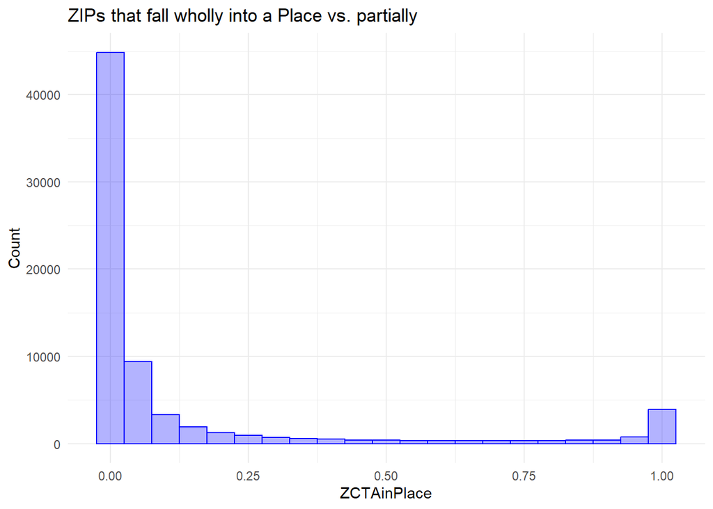

```r
# Visualize ZCTAinPlace showing distribution of ZIPs that fall wholly into a Place vs. partially

ZCTA_Place |>
    ggplot(aes(x = ZCTAinPlace )) +
    geom_histogram(color = "blue", fill = alpha("blue", 0.3), binwidth = 0.05) +
    labs(
      title = paste0("ZIPs that fall wholly into a Place vs. partially"),
      y = "Count",
      x = "ZCTAinPlace"
    ) +
    theme_minimal()
```

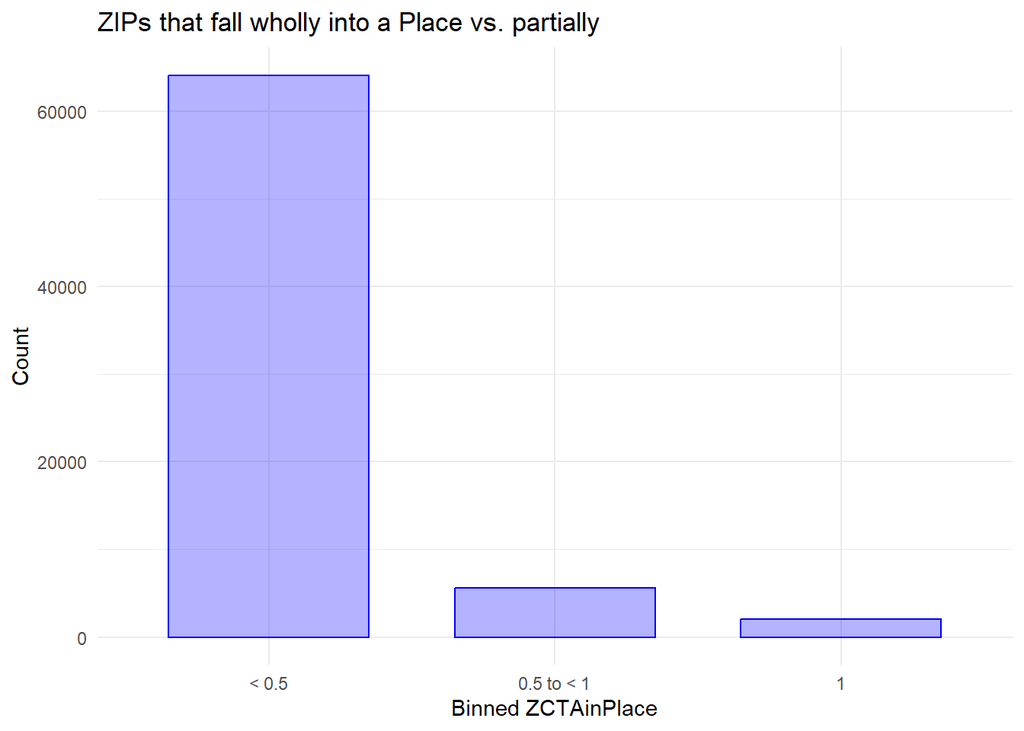

```r
# Visualize binned version of ZCTAinPlace showing distribution of ZIPs that fall wholly into a Place vs. partially

ZCTA_Place |>
    mutate(
      ZCTAinPlace_binned = case_when(
                                ZCTAinPlace == 1 ~ "1",
                                ZCTAinPlace >= 0.5 & ZCTAinPlace < 1 ~ "0.5 to < 1",
                                ZCTAinPlace < 0.5 ~ "< 0.5"),
      ZCTAinPlace_binned = factor(ZCTAinPlace_binned, levels = c("< 0.5", "0.5 to < 1", "1")
      )) |>
    ggplot(aes(x = ZCTAinPlace_binned )) +
    geom_bar(color = "blue", fill = alpha("blue", 0.3)) +
    labs(
      title = paste0("ZIPs that fall wholly into a Place vs. partially"),
      y = "Count",
      x = "Binned ZCTAinPlace"
    ) +
    theme_minimal()
```

At this stage we need to merge the Opportunity Insights data at the ZCTA level with the ZCTA to Place crosswalk that we cleaned up above. This will help map the economic connectedness data at the ZCTA level to corresponding Places that a ZIP code is associated with.

```r
# merge the ZIP/Places crosswalk into the economic connectedness data (left join, since places file has more observations)
merged_ec_city <- left_join(ZCTA_Place, ec_zip_raw, by=c("state", "zip"))
## Observation: Number of obs after merge is 71790

# check if there is missingness after the merge
merged_ec_city |>
  group_by(state) |>
  summarize(na_state_counts = sum(is.na(ec_zip))) |>
  print(n=56)
```

```
# A tibble: 56 × 2
   state na_state_counts
   <chr>           <int>
 1 01                302
 2 02                336
 3 04                340
 4 05                483
 5 06                839
 6 08                243
 7 09                104
 8 10                 21
 9 11                 50
10 12                161
11 13                319
12 15                 57
```

[output cut: 44 more lines]

```r
## Observation: Distribution of N/As across states looks fine
```

```r
# drop N/A values
merged_ec_city <- merged_ec_city %>%
        drop_na(ec_zip)
## Observation: Number of obs dropped to 54042 after removing `NA` values for economic connectedness
```

## Collapse Estimates to Unique Places

The final data must be reported at the `Place` level so we need to identify unique places and the ZCTAs they are linked to. This will help create a measure of number of ZCTAs linked with a place i.e. the `num_ZCTAs_in_place` variable.

```r
# Exploring options for data quality marker

# create a new variable `num_ZCTAs_in_place` that tracks the number of ZCTAs falling in each Place (duplicates)
# Set the year to 2022 for merging
merge_year <- c(2022)

merged_ec_city <- merged_ec_city |>
                                arrange(state, place) |>
## Changed logic of the previous version of this code to group by `state, place, place_name`
# instead of just `place, place_name`, otherwise places with same FIPS and name were getting counted
# across states leading to inflated values in `num_ZCTAs_in_place` variable
                                group_by(state, place, place_name) |>
                                mutate(
                                  # Changed logic of the previous version of this code to count distinct number
                                  # of ZIP codes linked to each place instead of counting grouped no. of rows
                                  num_ZCTAs_in_place = n_distinct(zip),
                                  year = merge_year
                                  )
```

Now, we define a variable `zip_total` which will give the total number of ZCTAs associated with a Place after we group our ZCTA level data by the unique places in a state. `zip_total` is calculated by averaging the `num_ZCTAs_in_place` variable which gives for each ZCTA level observation, the no. of ZCTAs its associated Place is linked with. On grouping at the Place level, this number should ideally be the same for all ZCTA level observations linked to a Place which is why we use an average.

We also create variable `zips_in` to indicate the number of ZCTAs which are fully encompassed within a Place geography by summing the `portion_in` variable at the Place level for each state.

Lastly, calculate a weighted average of economic connectedness for each Place, weighted by the percentage area of the ZCTA in that place (i.e. the `ZCTAinPlace` variable).

```r
# create the merged file where the economic connectedness variable is averaged per Place
# (new_ec_zip_to_place), weighted by the % area of the ZCTA in that Place
# and also include total ZCTAs in Place & how many of those partially fall outside the Place


wtd_merged_ec_city <- merged_ec_city |>
                        group_by(state, place, place_name) |>
                        summarize(
                                  # create variable for number of ZIPs present in a place
                                  zip_total = mean(num_ZCTAs_in_place),
                                  # create variable aggregating portion of ZIPs falling fully in a place
                                  zips_in = sum(portion_in),
                                  # create variable for weighted mean of economic connectedness
                                  new_ec_zip_to_place = weighted.mean(ec_zip, ZCTAinPlace),
                                  year = merge_year
                              )

# check for missingness
sum(is.na(wtd_merged_ec_city$new_ec_zip_to_place))
```

```
[1] 1919
```

```r
# drop missing values
wtd_merged_ec_city <- wtd_merged_ec_city |>
                          drop_na(new_ec_zip_to_place)
## Observation: lost 1919 observations (25030 minus 23111)
```

## Limit Places Based on Population-Cutoff

To get the final places required for the metric, we use the place to populations crosswalk i.e. `place-populations.csv`.

```r
# bring in the updated population-cutoff Places file
places_pop <- read_csv(here::here("geographic-crosswalks", "data",
                                  "place-populations.csv"))

# adapt variables to prepare for merge
places_pop <- places_pop |>
                        mutate(
                          state = str_pad(state, width = 2, pad = "0", side = "left"),
                          place = str_pad(place, width = 5, pad = "0", side = "left")
                          )

# keep only 2020 data to prepare for merge (should leave us with 486 obs total)
keep <- c(2020)

places_pop <- places_pop |>
                  filter(year %in% keep) |>
                  select(! year) # Keep only `merge_year` when merging
## Observation: 486 places available for year 2020
```

Merge the economic connectedness data with the place to populations crosswalk to get the final data points we need for the cities under consideration of the UMF project.

```r
# merge `places_pop` with data file in order to get final Economic Connectedness city data
ec_city_data <- left_join(places_pop, wtd_merged_ec_city, by=c("state", "place"))

# check if there are missings
ec_city_data <- ec_city_data |>
                    drop_na(new_ec_zip_to_place)
## Observation: no missing values! Total cities/places: 486
```

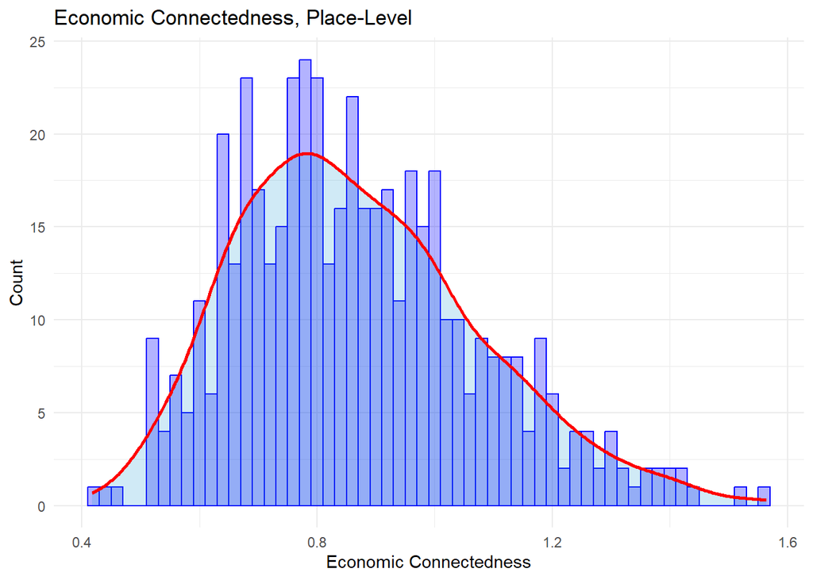

```r
# Visualize economic connectedness before updating

ec_city_data |>
    drop_na() |>
    ggplot(aes(x = new_ec_zip_to_place)) +
    geom_histogram(color = "blue", fill = alpha("blue", 0.3), binwidth = 0.02) +
    geom_density(aes(y = ..count.. * 0.02), color = "red", size = 1, alpha = 0.2) +
    labs(
      title = paste0("Economic Connectedness, Place-Level"),
      y = "Count",
      x = "Economic Connectedness"
    ) +
    theme_minimal()
```

## Update the Economic Connectedness variable

The Opportunity Insights group (Chetty et al.) via the Social Capital Atlas define economic connectedness as:

> the share of friends with above-median SES (‘high SES’) among people with below-median SES (‘low SES’) divided by 50%, to quantify the average degree of under-representation of high-SES friends among people with low SES.

The new Social Capital Atlas dashboard displays economic connectedness as both **the percentage of friends of those with low SES (Socio-Economic Status) that have high SES** and the **standardized percentile of that ratio nationwide**.

The Social Capital Atlas data set from 2022 provides the scaled economic connectedness variable per the definition mentioned above. We need to transform it into the “percentage of friends of those with low SES that have high SES” as displayed on the Social Capital Atlas. For this purpose, we will multiply the scaled economic connectedness variable with 50% to get the desired percentage representation of economic connectedness.

This example illustrates the update we need to make:

EXAMPLE: Fairfax County, VA

- Urban’s Mobility Metrics Economic Connectedness: 1.2 (this value is a result of rounding done by the Upward Mobility Initiative (UMI) for its display of metrics)
- Social Capital Atlas Raw Data Economic Connectedness: 1.185
- Social Capital Atlas Website: Economic Connectedness - Fairfax County, VA (Click `Explore the Data` once you navigate to the link)
  - The Social Capital Atlas website displays the economic connectedness for Fairfax County, VA as “59.3 % of friends are high-income” and indicates that the county falls in the 99th percentile nationwide.
- This difference in presentation comes down to displaying the raw percentage of high SES friends vs the calculated ratio.
  - E.g., 59.3 / 50 = 1.186

```r
# update economic connectedness scaled variable by multiplying it with 50% (i.e. 0.5) to get the percentage values

ec_city_data <- ec_city_data |>
                    mutate(share_economic_connectedness = new_ec_zip_to_place * 0.5)
```

```r
quantile(ec_city_data$share_economic_connectedness, na.rm=TRUE)
```

```
       0%       25%       50%       75%      100%
0.2085973 0.3582457 0.4241414 0.4973955 0.7819429
```

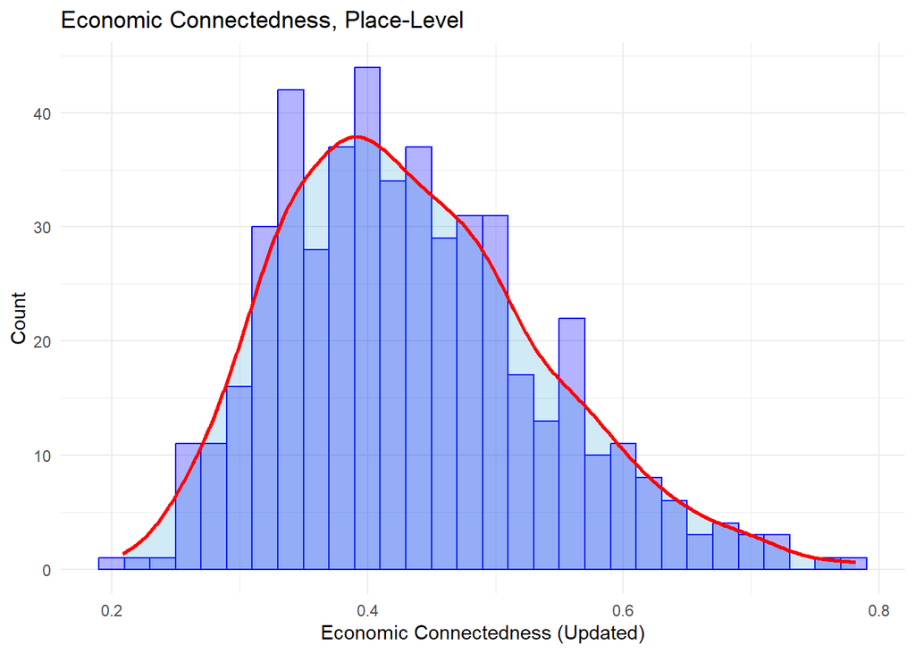

```r
 ec_city_data |>
    drop_na() |>
    ggplot(aes(x = share_economic_connectedness)) +
    geom_histogram(color = "blue", fill = alpha("blue", 0.3), binwidth = 0.02) +
    geom_density(aes(y = ..count.. * 0.02), color = "red", size = 1, alpha = 0.2) +
    labs(
      title = paste0("Economic Connectedness, Place-Level"),
      y = "Count",
      x = "Economic Connectedness (Updated)"
    ) +
    theme_minimal()
```

The updated economic connectedness metric in the above plot shows the share (percentage as proportion) of friends of those with low SES (Socio-Economic Status) that have high SES, i.e. the share of friends who are high income.

## Incorporate data quality measures

Next step is to create a data quality flag for the updated economic connectedness metric. This involves creating a measure (variable `zip_ratio`) to track the number of ZIPs that were aggregated which are entirely present in a Census designated Place. Using this new variable `zip_ratio`, data quality for the economic connectedness metric is defined as:

- Data Quality `1` = 50% or more of the ZIPs fall fully (>50%) in the census place
- Data Quality `2` = 15% to 50% of the ZIPs fall fully (>50%) in the census place
- Data Quality `3` = less than 15% of the ZIPs fall fully into the census place

Here, the highest data quality is `1` while `3` is the lowest. For places that don’t have a metric value, a data quality of `NA` is assigned.

```r
# create a ratio value to see how many of the ZIPs we aggregated fell fully into a Census Place boundary
ec_city_data <- ec_city_data |>
                     mutate(zip_ratio = zips_in/zip_total)

# check the range on this
summary(ec_city_data)
```

```
    state              place            state_name        place_name.x
 Length:486         Length:486         Length:486         Length:486
 Class :character   Class :character   Class :character   Class :character
 Mode  :character   Mode  :character   Mode  :character   Mode  :character



   population      place_name.y         zip_total         zips_in
 Min.   :  74793   Length:486         Min.   :  2.00   Min.   :  0.000
 1st Qu.:  91564   Class :character   1st Qu.:  7.00   1st Qu.:  0.000
 Median : 117356   Mode  :character   Median : 10.00   Median :  0.000
 Mean   : 227414                      Mean   : 13.95   Mean   :  2.572
 3rd Qu.: 199522                      3rd Qu.: 14.00   3rd Qu.:  2.000
 Max.   :8804190                      Max.   :186.00   Max.   :162.000
 new_ec_zip_to_place      year      share_economic_connectedness
 Min.   :0.4172      Min.   :2022   Min.   :0.2086
 1st Qu.:0.7165      1st Qu.:2022   1st Qu.:0.3582
 Median :0.8483      Median :2022   Median :0.4241
 Mean   :0.8694      Mean   :2022   Mean   :0.4347
 3rd Qu.:0.9948      3rd Qu.:2022   3rd Qu.:0.4974
 Max.   :1.5639      Max.   :2022   Max.   :0.7819
   zip_ratio
 Min.   :0.00000
 1st Qu.:0.00000
 Median :0.00000
 Mean   :0.09326
 3rd Qu.:0.14954
 Max.   :1.00000
```

```r
## Observation: zip_ratio mean = 0.09326, Q1 = 0, Q3 = 0.14954
```

```r
# Data Quality 1 = 50% or more of the ZIPs fall fully (>50%) in the census place
# Data Quality 2 = 15% to 50% of the ZIPs fall fully (>50%) in the census place
# Data Quality 3 = less than 15% of the ZIPs fall fully into the census place

# create the data quality flag
ec_city_data <- ec_city_data |>
                        mutate(
                          share_economic_connectedness_quality =
                            case_when(
                              zip_ratio >= 0.5 ~ 1,
                              zip_ratio < 0.5 & zip_ratio > 0.15 ~ 2,
                              zip_ratio < 0.15 ~ 3,
                              .default = NA_integer_
                              )
                          )
```

## Evaluate and export final data

```r
# check if there are any missing places

missing_places <- anti_join(ec_city_data, places_pop, by = c("state", "place"))
# in this data, we find that there are no missing cities
print(missing_places)
```

```
# A tibble: 0 × 13
# ℹ 13 variables: state <chr>, place <chr>, state_name <chr>,
#   place_name.x <chr>, population <dbl>, place_name.y <chr>, zip_total <dbl>,
#   zips_in <dbl>, new_ec_zip_to_place <dbl>, year <dbl>,
#   share_economic_connectedness <dbl>, zip_ratio <dbl>,
#   share_economic_connectedness_quality <dbl>
```

```r
# check for number of places with NA metric values
sum(is.na(ec_city_data$share_economic_connectedness))
```

```
[1] 0
```

```r
## there are no cities with NA metric values

# keep only relevant data
ec_final_data <- ec_city_data |>
                  select(year, state, place, share_economic_connectedness,
                          share_economic_connectedness_quality)
```

After generating the final data, we need to evaluate the outputs using the `evaluate_final_data` function per UMF [guidelines](https://github.com/UI-Research/mobility-from-poverty/wiki/8_Final-Data-Expectations-Form%E2%80%AF).

```r
evaluate_final_data(
    exp_form_path =
      here::here("10a_final-evaluation", "evaluation_form_social_cap2_overall_place.csv"),
    data = ec_final_data, geography = "place",
    subgroups = FALSE, confidence_intervals = FALSE)
```

```
[1] "This data passes all tests!"
```

After successfully evaluating the final data, store the final data file `economic_connectedness_version2025_place_2022.csv` in folder `06_neighborhoods/social-capital/final/`.

```r
# Define file path to save the final data file
file_path <- here::here(
      "06_neighborhoods", "social-capital", "final",
      "economic_connectedness_version2025_place_2022.csv"
      )

# Save the csv file
write.csv(ec_final_data, file_path, row.names = FALSE)
```